# Data Challenge

## Content:

1. Data Preprocessing
2. Model selection
3. Model 1 and Model 2

### Data Preprocessing:

##### Class 0 have almost 99.85% data points and Class 1 have only .17% datapoints. My aim is to do Under samling from Class 0 without any information loss. I can simply drop the duplicate for sure.

##### Class 1 over sampling:

One way to do the over sampling is to just repeat the data. This is a good approach but It leads to the overfitting of the class. Another appoach would be to generate the senthetic data and add it to the data points. Senthetic data can be created by adding the Guassian noise to the given data points. One more way to create the senthetic data is a technique called SMOTE (Synthetic Minority Over-sampling Technique) https://jair.org/index.php/jair/article/view/10302

I understand these is a better approach than just simply copy the data but I am processing forward by copying the data because of time constraints.

### Model Selection?

The Classes are unevenly distributed. Therefore, I can think of this problem as Class 0 define healthy population and Class 1 as patients. My goal is to focus on classifying the patient correctly. I believe models based on cost matrix would be best for this scenario. It would be great idea to give more positive weight to correct classification of class 1 and more negative weight or penalty to misclassify class 1 as compare to class 0. I don't have cost matrix though.

## Model 1:

1. QDA: Quadratic discriminant analysis: The main assumption of the QDA is that the distribution of each feature should be Guassian.

### Process to generate the model:

This process focus on the over sampling on class 1 and under sampling of class 0.

#### Steps:

1. Double the size of class 1. (984).

#### Note:

1. I could choose the bagging method in place of above defining method. But in my opinion bagging would not be better in this case since the minority class have only .17% datapoints and after over sampling this would not effect much too.Moreover, I cannot do over sampling any large number of time. This would affect the reliability of classifier. As it would end up been overfitting.

### Recall or Precision?

#### It depends on how much cost/weight you want on your two types of errors:

###### (1) False Positives or (2) False Negatives

###### What's the cost of having a FN and FP?

###### Optimize Recall When:

1. If I want to limit false negatives
2. I will get more False Positives
3. FN > FP
4. Example: Predicting Cancer Patients or Credit Card Fraud

##### Optimize Precision When:

1. If Iwant to limit false positives
2. FP > FN
3. Example: Spam VS Not Spam

### Here I am treating class 1 as a patient class therefore my aim is to optimize recall

```python
# import libraries
import pandas as pd
import numpy as np
from sklearn.discriminant_analysis import QuadraticDiscriminantAnalysis
from sklearn.metrics import recall_score
import matplotlib.pyplot as plt
from sklearn import decomposition
from sklearn.model_selection import train_test_split
```

```python
# Files without missing value
df_0=pd.read_csv('Class_0_no_null')
df_1=pd.read_csv('New_Class_1_no_null')
```

```python
df_0.columns
```

```
Index(['Unnamed: 0', 'V1', 'V2', 'V3', 'V4', 'V5', 'V6', 'V7', 'V8', 'V9',
       'V10', 'V11', 'V12', 'V13', 'V14', 'V15', 'V16', 'V17', 'V18', 'V19',
       'V20', 'V21', 'V22', 'V23', 'V24', 'V25', 'V26', 'V27', 'V28', 'V29',
       'Class'],
      dtype='object')
```

```python
# df_0 contains the features of class 0
df_0=df_0.drop(columns=['Unnamed: 0','Class'])

# df_0 contains the features of class 1
df_1=df_1.drop(columns=['Unnamed: 0','Class'])
```

Double the size of class 1 by just copying it again.

```python
df_1=df_1.append(df_1)
```

#### Model 1 by Quadratic discriminant analysis

```python
import numpy as np
from sklearn.discriminant_analysis import QuadraticDiscriminantAnalysis
from sklearn.metrics import recall_score

df_exp=df_0.sample(n=900)
df_exp=df_exp.append(df_1.sample(n=900))
Class= np.append(np.zeros(900),np.ones(900))
from sklearn.model_selection import train_test_split
recall=[]
for i in range(1,100):
    df_exp=df_0.sample(n=900)
    df_exp=df_exp.append(df_1.sample(n=900))
    X_train1, X_test1, y_train1, y_test1 = train_test_split(df_exp, Class,test_size=0.4, random_state=i)
    qda1 = QuadraticDiscriminantAnalysis()
    qda1.fit(X_train1, y_train1)

    pred = qda1.predict(X_test1)
    recall.append(recall_score(y_test1, qda1.predict(X_test1)))
print('Recall: ')
print(sum(recall) / float(len(recall)) )
```

```
Recall:
0.9187273100216595
```

#### Apply QDA on the whole dataset and calculate the Confusion Matrix

```python
from sklearn.pipeline import make_pipeline
df_exp=df_0
df_exp=df_exp.append(df_1)
Class= np.append(np.zeros(len(df_0)),np.ones(len(df_1)))
from sklearn.model_selection import train_test_split

X_train1, X_test1, y_train1, y_test1 = train_test_split(df_exp, Class,test_size=0.4, random_state=5)
model = QuadraticDiscriminantAnalysis()

model.fit(X_train1, y_train1)

pred = model.predict(X_test1)
print('Accuracy of QDA classifier on training set: {:.2f}'
     .format(model.score(X_train1, y_train1)))
print('Accuracy of QDA classifier on test set: {:.2f}'
     .format(model.score(X_test1, y_test1)))
from sklearn.metrics import confusion_matrix
recall=recall_score(y_test1, model.predict(X_test1))
print('Recall:')
print(recall)
pred = qda1.predict(X_test1)
print(confusion_matrix(y_test1, pred))
```

```
Accuracy of QDA classifier on training set: 0.97
Accuracy of QDA classifier on test set: 0.97
Recall:
0.8857868020304569
[[106396   7330]
 [    26    368]]
```

Visualize the decision boundary of QDA on PCA1 and PCA 2.

```
[9.99510679e-01 6.28833528e-05]
```

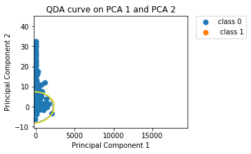

```python
import matplotlib.pyplot as plt

df_exp=df_0
df_exp=df_exp.append(df_1)
Y= np.append(np.zeros(len(df_0)),np.ones(len(df_1)))

h = .02  # step size in the mesh

target_names=["class 0"," class 1"]

from sklearn import decomposition
pca = decomposition.PCA(n_components=2)
pca.fit(df_exp)
X = pca.transform(df_exp)
qda1 = QuadraticDiscriminantAnalysis()
print(pca.explained_variance_ratio_)
qda1.fit(X,Y)

colors = ['navy', 'turquoise', 'darkorange']
# Plot the decision boundary. For that, we will assign a color to each
# point in the mesh [x_min, x_max]x[y_min, y_max].
x_min, x_max = X[:, 0].min() - .5, X[:, 0].max() + .5
y_min, y_max = X[:, 1].min() - .5, X[:, 1].max() + .5
xx, yy = np.meshgrid(np.linspace(x_min, x_max, 200), np.linspace(y_min, y_max, 200))

Z = qda1.predict(np.c_[xx.ravel(), yy.ravel()])
# Put the result into a color plot
Z = Z.reshape(xx.shape)
plt.figure(1, figsize=(4, 3))
plt.contour(xx, yy, Z, color = 'black')
for color, i, target_name in zip(colors, [1, 2, 3], target_names):
    plt.scatter(X[Y == i, 0], X[Y == i, 1], lw= 2,
                label=target_name)

plt.legend(bbox_to_anchor=(1.05, 1), loc=2, borderaxespad=0.)

plt.xlabel('Principal Component 1')
plt.ylabel('Principal Component 2')
plt.title('QDA curve on PCA 1 and PCA 2')
plt.xlim(xx.min(), xx.max())
plt.ylim(yy.min(), yy.max())

plt.show()
```

### Model 2

## Model 2:

Logistic Regression?

Logistic regression assumes the datapoints to be independent of each other. It also requires no co-linearity in the variables

In the given dataset, Class 1 has many features which are correlated. So I would not prefer to choose logistic regression. I could simply drop the features which are highly correlated to make the remaining feature space non linear but I may loss the information by just dropping so many features.

Conclusion: Not to choose Logistic regression.

Linear Discriminant Analysis (LDA)

Linear Discriminant Analysis assumes a Gaussian distribution for the numerical input variables.

LDA could also be a better choice as in my case also the distribution of the features are guassian but I am planning not to choose LDA because by looking at the graph between PCA1 and PCA 2, I find that linear classifier will give me more misclassification from Class 1.

Conclusion: Not to choose LDA.

#### My aim is to choose a non linear classifier

I have lot of overlapping datapoint as seen in PCA component graph therefore, I would avoid KNN.

Naive Bayes Classifier:calculates the probability of each class and the conditional probability of each class given each input value

Assumption: The conditional independence assumption states that features are independent of each other given the class.

I have lot of dependent features in Class 1. So I prefer to avoid Naive Bayes too.

##### Model 2 Support Vector Machines

SVM would be a better model in my case as there is no specific assumption for SVM. I have overlapping data with no clear boundary so SVM would help in mapping the space to higher dimmension my kernel trick and seperate the classes.

Model 2:

We can also specify the parameter such as class_weight. We can also change the kernal and compare the recall. kernel=’rbf’, degree=3, gamma.

```python
from sklearn.svm import SVC
from sklearn.pipeline import make_pipeline

df_exp=df_0.sample(n=900)
df_exp=df_exp.append(df_1.sample(n=900))
Class= np.append(np.zeros(900),np.ones(900))
recall=[]
for i in range(1,10):
    df_exp=df_0.sample(n=900)
    df_exp=df_exp.append(df_1.sample(n=900))
    X_train1, X_test1, y_train1, y_test1 = train_test_split(df_exp, Class,test_size=0.4, random_state=i)
    model = SVC(kernel='poly', gamma='scale')


    model.fit(X_train1,y_train1)

    pred = model.predict(X_test1)
    recall.append(recall_score(y_test1, model.predict(X_test1)))
print('Recall: ')
print(sum(recall) / float(len(recall)) )
```

```
Recall:
0.634938129434169
```

## Conclusion:

Recall was calculated by QDA and found to be 91.8% when I ran the experiment 100 times (select 100 random samples from the class 0 and run QDA) .

Recall was calculated by SVM and this time found to be 63.49% when I ran the experiment only 10 times.(select 10 random samples from the class 0 and run SVM)

Future work:

1. Run QDA atleast as many times as I could to make sure that I have covered all the information from class 0 or picked maximum number of different points.
2. This SVM result is not reliable. I should have run SVM as many times as I could to make sure that I have covered all information from class 0 or picked maximum number of different points. Moreover, tuning the parameters such as kernel( polynomial with different degree, sigmoid and 'RBF'), scaling the features, specify the class weights is also an important task.

QDA is much faster than the SVM in order to classify. Other classifier such as Decision tree and random forest is also a good option in this particular study.